# The identifier band dial on the J = 10 harm cells: minSG, effMaxSG at ε = 0.10 / 0.20 / 0.30, maxSG

- Show All Code
- Hide All Code
- View Source

Identification and the constructions on identical replicates (p30sg, nb20 arm A, banddial; TASK_complement_variance_banddial_2026-09-07, Part B)

Author

Larry León

Published

September 7, 2026

Five settings of the identifier on the same replicates of the two harm cells (HR 1.50 n500, HR 1.75 n500; 31% prevalence, J = 10, seeds 8316951 + sim_id): `minSG` (the smallest consistency-qualifying candidate of at least 60), `effMaxSG` at ε = 0.10 (`p30sg`), 0.20 (nb20 arm A `p30sgnb20`) and 0.30 (`banddial`), and `maxSG` (the largest consistency-qualifying candidate; `banddial`). The screened family and the consistency-qualifying set are identical across the five (same data, same J = 10 grid, same floors); only the pick changes. Constructions: naive as reference, MR (IJ two-term) and MR (field) on both blocks, the joint pair; winner-only and winner-floor excluded. “SD units” and “SD(β̃ᶜ)/naive SE” follow the reports’ convention (marginal SD of the log estimate); the error-scale ratio of `REPORT_complement_variance_2026-09-07` is shown beside it.

# 1 Bundles

```r
library(forestsearch)
library(ggplot2)
library(kableExtra)
`%||%` <- function(a, b) if (is.null(a) || length(a) == 0 || all(is.na(a))) b else a
settings <- list(
  list(key = "minSG",  label = "minSG",              glob = "results/fs_minSG_fb_mr_field_m1_%s_knoise0_n500_z1q60_banddial_combined_1_2000.rds"),
  list(key = "eps10",  label = "effMaxSG eps 0.10",  glob = "results/fs_effMaxSG_fb_mr_field_m1_%s_knoise0_n500_z1q60_p30sg_combined_1_2000.rds"),
  list(key = "eps20",  label = "effMaxSG eps 0.20",  glob = "results/fs_effMaxSG_fb_mr_field_m1_%s_knoise0_n500_z1q60_nb20_p30sgnb20_combined_1_2000.rds"),
  list(key = "eps30",  label = "effMaxSG eps 0.30",  glob = "results/fs_effMaxSG_fb_mr_field_m1_%s_knoise0_n500_z1q60_nb30_banddial_combined_1_2000.rds"),
  list(key = "maxSG",  label = "maxSG",              glob = "results/fs_maxSG_fb_mr_field_m1_%s_knoise0_n500_z1q60_banddial_combined_1_2000.rds"))
cells <- c(h150 = "HR 1.50 n500", h175 = "HR 1.75 n500")
B <- lapply(names(cells), function(h) { out <- lapply(settings, function(s) { f <- sprintf(s$glob, h); if (file.exists(f)) readRDS(f) else NULL }); names(out) <- vapply(settings, `[[`, "", "key"); out })
names(B) <- names(cells)
avail <- do.call(rbind, lapply(names(B), function(h) data.frame(cell = cells[[h]], setting = vapply(settings, `[[`, "", "label"), present = !vapply(B[[h]], is.null, TRUE),
  n_true_identical = vapply(B[[h]], function(b) if (is.null(b)) NA else all(b$results$n_true[order(b$results$sim_id)] == B[[h]]$eps20$results$n_true[order(B[[h]]$eps20$results$sim_id)]), NA),
  truth_identical = vapply(B[[h]], function(b) if (is.null(b)) NA else identical(b$truth, B[[h]]$eps20$truth), NA))))
kbl(avail, booktabs = TRUE, row.names = FALSE, caption = "Bundles read; same draws asserted against nb20 arm A (n_true and truth identical).") |> kable_styling(font_size = 11)
```

Bundles read; same draws asserted against nb20 arm A (n_true and truth identical).

| cell | setting | present | n_true_identical | truth_identical |
| --- | --- | --- | --- | --- |
| HR 1.50 n500 | minSG | TRUE | TRUE | TRUE |
| HR 1.50 n500 | effMaxSG eps 0.10 | TRUE | TRUE | TRUE |
| HR 1.50 n500 | effMaxSG eps 0.20 | TRUE | TRUE | TRUE |
| HR 1.50 n500 | effMaxSG eps 0.30 | TRUE | TRUE | TRUE |
| HR 1.50 n500 | maxSG | TRUE | TRUE | TRUE |
| HR 1.75 n500 | minSG | TRUE | TRUE | TRUE |
| HR 1.75 n500 | effMaxSG eps 0.10 | TRUE | TRUE | TRUE |
| HR 1.75 n500 | effMaxSG eps 0.20 | TRUE | TRUE | TRUE |
| HR 1.75 n500 | effMaxSG eps 0.30 | TRUE | TRUE | TRUE |
| HR 1.75 n500 | maxSG | TRUE | TRUE | TRUE |

# 2 The dial table (identical replicates)

```r
wil <- function(x, n, z = qnorm(.975)) { c <- (x + z^2/(2*n))/(1+z^2/n); h <- z*sqrt(x*(1-x)/n + z^2/(4*n^2))/(1+z^2/n); c(c - h, c + h) }
dial_one <- function(b, common_ids) {
  r <- b$results; r <- r[order(r$sim_id), ]; d <- r[r$detected %in% 1L & r$sim_id %in% common_ids, ]
  tr <- b$truth; thH <- as.numeric(tr$marg_H); thHc <- as.numeric(tr$marg_Hc)
  rt <- d$n_harm / d$n_true
  col <- function(nm) if (is.null(d[[nm]])) rep(NA_real_, nrow(d)) else d[[nm]]   # p-hat / band / family columns are absent on p30sg
  for (nm in c("p_hat_H", "p_hat_top1", "p_hat_top2", "p_hat_top3", "band_n", "n_cons_qual", "n_family")) d[[nm]] <- col(nm)
  optH <- log(d$nv_H_est) - log(d$betaHhat_H); optC <- log(d$nv_Hc_est) - log(d$betaHhat_Hc)
  e_c <- log(d$mr_Hc_est) - log(d$betaHhat_Hc); nse <- sqrt(mean(d$nv_Hc_se^2))
  top3 <- rowSums(cbind(d$p_hat_top1, d$p_hat_top2, d$p_hat_top3), na.rm = TRUE)
  q <- function(v, p) unname(stats::quantile(v, p, na.rm = TRUE))
  c(`detection (all replicates)` = mean(r$detected %in% 1L),
    `n (common detected)` = nrow(d),
    `mean |Hhat|` = mean(d$n_harm), `|Hhat|/|H| median` = q(rt, .5), `|Hhat|/|H| q10` = q(rt, .1), `|Hhat|/|H| q90` = q(rt, .9),
    `share |Hhat| >= |H| (planted size)` = mean(d$n_harm >= d$n_true), `share |Hhat| >= 0.9|H|` = mean(rt >= 0.9),
    sens = mean(d$sens, na.rm = TRUE), spec = mean(d$spec, na.rm = TRUE), ppv = mean(d$ppv, na.rm = TRUE), npv = mean(d$npv, na.rm = TRUE),
    `naive optimism Hhat: log-HR` = mean(optH), `naive optimism Hhat: SD units (marginal)` = mean(optH) / sd(log(d$nv_H_est)), `naive optimism Hhat: error-SD units` = mean(optH) / sd(optH),
    `naive optimism Hhat^c: log-HR` = mean(optC), `naive optimism Hhat^c: SD units (marginal)` = mean(optC) / sd(log(d$nv_Hc_est)),
    `mean beta(Hhat)` = mean(d$betaHhat_H), `theta-dagger(H)` = thH, `mean beta(Hhat^c)` = mean(d$betaHhat_Hc), `theta-dagger(H^c)` = thHc,
    `SD(beta-tilde^c)/naive SE (marginal)` = sd(log(d$mr_Hc_est)) / nse, `SD(e^c)/naive SE (error)` = sd(e_c) / nse, `lambda-SD^c/naive SE` = sqrt(mean(d$fld_Hc_se^2)) / nse,
    `SD(beta-tilde)/naive SE (marginal, Hhat)` = sd(log(d$mr_H_est)) / sqrt(mean(d$nv_H_se^2)), `SD(e)/naive SE (error, Hhat)` = sd(log(d$mr_H_est) - log(d$betaHhat_H)) / sqrt(mean(d$nv_H_se^2)),
    `p-hat(Hhat) mean` = mean(d$p_hat_H, na.rm = TRUE), `p-hat(Hhat) median` = q(d$p_hat_H, .5), `share p-hat = argmax` = mean(abs(d$p_hat_H - d$p_hat_top1) < 1e-12, na.rm = TRUE), `top-3 mass` = mean(top3),
    `band size (eps of the bundle)` = mean(d$band_n, na.rm = TRUE), `consistency-qualifying` = mean(d$n_cons_qual, na.rm = TRUE), `family K` = mean(d$n_family, na.rm = TRUE),
    `complement fits/rep` = mean(d$fld_Hc_nfit, na.rm = TRUE), `fit+MR s/rep` = mean(d$fit_mr_secs, na.rm = TRUE))
}
DIAL <- list()
for (h in names(B)) {
  bs <- B[[h]][!vapply(B[[h]], is.null, TRUE)]
  common <- Reduce(intersect, lapply(bs, function(b) b$results$sim_id[b$results$detected %in% 1L]))
  M <- sapply(bs, dial_one, common_ids = common)
  colnames(M) <- vapply(settings[match(names(bs), vapply(settings, `[[`, "", "key"))], `[[`, "", "label")
  DIAL[[h]] <- M
  print(kbl(M, digits = 3, booktabs = TRUE, caption = sprintf("%s: the dial on the %d replicates detected under every setting (p-hat, band and family columns are NA where the bundle predates their recording).", cells[[h]], length(common))) |> kable_styling(font_size = 11))
}
```

[output not shown]

[output cut: 534 more lines]

[output not shown]

# 3 Constructions: one-sided coverage on both blocks at each setting

```r
estimators <- c("naive", "mr", "fld")
lab_of <- function(key) settings[[match(key, vapply(settings, `[[`, "", "key"))]]$label
COV <- do.call(rbind, lapply(names(B), function(h) do.call(rbind, lapply(names(B[[h]]), function(k) { b <- B[[h]][[k]]; if (is.null(b)) return(NULL)
  rbind(cbind(cell = cells[[h]], setting = lab_of(k), block = "Hhat (lower)", fs_sim_bias_coverage(b$results, block = "H", estimators = estimators, side = "lower")),
        cbind(cell = cells[[h]], setting = lab_of(k), block = "Hhat^c (upper)", fs_sim_bias_coverage(b$results, block = "Hc", estimators = estimators, side = "upper"))) }))))
COV$estimator <- factor(COV$estimator, levels = c("naive", "mr", "fld"), labels = c("naive", "IJ two-term", "field"))
COV$setting <- factor(COV$setting, levels = vapply(settings, `[[`, "", "label"))
COV <- COV[order(COV$cell, COV$block, COV$setting, COV$estimator), ]
kbl(COV[, c("cell", "block", "setting", "estimator", "n", "bias_log", "sd_emp", "se_mean", "b", "r", "cov1", "cov1_wilson_lo", "cov1_wilson_hi", "cov2", "cov1_ref")],
    digits = 3, booktabs = TRUE, row.names = FALSE,
    caption = "cov1 = one-sided 95% coverage of beta(Hhat) by the lower bound / of beta(Hhat^c) by the upper bound, Wilson limits; b = bias / marginal SD, r = mean SE / marginal SD; cov1_ref = Gaussian reference.") |>
  kable_styling(font_size = 10)
```

cov1 = one-sided 95% coverage of beta(Hhat) by the lower bound / of beta(Hhat^c) by the upper bound, Wilson limits; b = bias / marginal SD, r = mean SE / marginal SD; cov1_ref = Gaussian reference.

| cell | block | setting | estimator | n | bias_log | sd_emp | se_mean | b | r | cov1 | cov1_wilson_lo | cov1_wilson_hi | cov2 | cov1_ref |
| --- | --- | --- | --- | --- | --- | --- | --- | --- | --- | --- | --- | --- | --- | --- |
| HR 1.50 n500 | Hhat (lower) | minSG | naive | 1999 | 0.384 | 0.189 | 0.320 | 2.032 | 1.691 | 0.752 | 0.733 | 0.771 | 0.852 | 0.773 |
| HR 1.50 n500 | Hhat (lower) | minSG | IJ two-term | 1999 | 0.098 | 0.236 | 0.382 | 0.415 | 1.624 | 0.974 | 0.967 | 0.981 | 0.989 | 0.988 |
| HR 1.50 n500 | Hhat (lower) | minSG | field | 1999 | 0.032 | 0.265 | 0.313 | 0.121 | 1.181 | 0.942 | 0.931 | 0.951 | 0.935 | 0.966 |
| HR 1.50 n500 | Hhat (lower) | effMaxSG eps 0.10 | naive | 1999 | 0.548 | 0.221 | 0.287 | 2.478 | 1.299 | 0.381 | 0.360 | 0.402 | 0.542 | 0.367 |
| HR 1.50 n500 | Hhat (lower) | effMaxSG eps 0.10 | IJ two-term | 1999 | 0.071 | 0.274 | 0.386 | 0.260 | 1.408 | 0.978 | 0.971 | 0.984 | 0.983 | 0.980 |
| HR 1.50 n500 | Hhat (lower) | effMaxSG eps 0.10 | field | 1999 | -0.003 | 0.300 | 0.337 | -0.009 | 1.123 | 0.970 | 0.962 | 0.977 | 0.938 | 0.968 |
| HR 1.50 n500 | Hhat (lower) | effMaxSG eps 0.20 | naive | 1999 | 0.430 | 0.238 | 0.250 | 1.809 | 1.049 | 0.484 | 0.462 | 0.506 | 0.619 | 0.467 |
| HR 1.50 n500 | Hhat (lower) | effMaxSG eps 0.20 | IJ two-term | 1999 | -0.003 | 0.279 | 0.360 | -0.011 | 1.289 | 0.985 | 0.979 | 0.990 | 0.981 | 0.983 |
| HR 1.50 n500 | Hhat (lower) | effMaxSG eps 0.20 | field | 1999 | -0.056 | 0.299 | 0.324 | -0.185 | 1.081 | 0.974 | 0.967 | 0.981 | 0.925 | 0.975 |
| HR 1.50 n500 | Hhat (lower) | effMaxSG eps 0.30 | naive | 1999 | 0.299 | 0.224 | 0.213 | 1.332 | 0.949 | 0.633 | 0.612 | 0.654 | 0.735 | 0.590 |
| HR 1.50 n500 | Hhat (lower) | effMaxSG eps 0.30 | IJ two-term | 1999 | -0.068 | 0.254 | 0.334 | -0.266 | 1.311 | 0.995 | 0.991 | 0.997 | 0.987 | 0.992 |
| HR 1.50 n500 | Hhat (lower) | effMaxSG eps 0.30 | field | 1999 | -0.093 | 0.270 | 0.298 | -0.344 | 1.103 | 0.980 | 0.973 | 0.986 | 0.937 | 0.985 |
| HR 1.50 n500 | Hhat (lower) | maxSG | naive | 1999 | 0.082 | 0.055 | 0.142 | 1.472 | 2.562 | 0.943 | 0.932 | 0.952 | 0.971 | 0.997 |
| HR 1.50 n500 | Hhat (lower) | maxSG | IJ two-term | 1999 | 0.016 | 0.065 | 0.218 | 0.238 | 3.328 | 0.999 | 0.997 | 1.000 | 0.997 | 1.000 |
| HR 1.50 n500 | Hhat (lower) | maxSG | field | 1999 | 0.002 | 0.076 | 0.128 | 0.024 | 1.692 | 0.949 | 0.938 | 0.958 | 0.946 | 0.997 |
| HR 1.50 n500 | Hhat^c (upper) | minSG | naive | 1999 | -0.056 | 0.141 | 0.131 | -0.398 | 0.925 | 0.867 | 0.852 | 0.882 | 0.911 | 0.869 |
| HR 1.50 n500 | Hhat^c (upper) | minSG | IJ two-term | 1999 | -0.022 | 0.139 | 0.253 | -0.161 | 1.818 | 0.997 | 0.993 | 0.999 | 1.000 | 0.998 |
| HR 1.50 n500 | Hhat^c (upper) | minSG | field | 1999 | -0.015 | 0.139 | 0.130 | -0.105 | 0.936 | 0.923 | 0.911 | 0.934 | 0.941 | 0.924 |
| HR 1.50 n500 | Hhat^c (upper) | effMaxSG eps 0.10 | naive | 1999 | -0.112 | 0.147 | 0.136 | -0.762 | 0.926 | 0.793 | 0.775 | 0.810 | 0.867 | 0.777 |
| HR 1.50 n500 | Hhat^c (upper) | effMaxSG eps 0.10 | IJ two-term | 1999 | -0.041 | 0.147 | 0.251 | -0.278 | 1.704 | 0.996 | 0.993 | 0.998 | 0.999 | 0.994 |
| HR 1.50 n500 | Hhat^c (upper) | effMaxSG eps 0.10 | field | 1999 | -0.029 | 0.149 | 0.132 | -0.194 | 0.888 | 0.913 | 0.900 | 0.925 | 0.937 | 0.897 |
| HR 1.50 n500 | Hhat^c (upper) | effMaxSG eps 0.20 | naive | 1999 | -0.123 | 0.156 | 0.143 | -0.789 | 0.912 | 0.781 | 0.762 | 0.798 | 0.849 | 0.762 |
| HR 1.50 n500 | Hhat^c (upper) | effMaxSG eps 0.20 | IJ two-term | 1999 | -0.044 | 0.157 | 0.257 | -0.282 | 1.636 | 0.995 | 0.991 | 0.997 | 1.000 | 0.992 |
| HR 1.50 n500 | Hhat^c (upper) | effMaxSG eps 0.20 | field | 1999 | -0.031 | 0.159 | 0.135 | -0.193 | 0.852 | 0.897 | 0.883 | 0.910 | 0.921 | 0.886 |
| HR 1.50 n500 | Hhat^c (upper) | effMaxSG eps 0.30 | naive | 1999 | -0.137 | 0.162 | 0.153 | -0.844 | 0.944 | 0.774 | 0.755 | 0.792 | 0.854 | 0.761 |
| HR 1.50 n500 | Hhat^c (upper) | effMaxSG eps 0.30 | IJ two-term | 1999 | -0.047 | 0.164 | 0.266 | -0.289 | 1.625 | 0.996 | 0.992 | 0.998 | 1.000 | 0.991 |
| HR 1.50 n500 | Hhat^c (upper) | effMaxSG eps 0.30 | field | 1999 | -0.031 | 0.167 | 0.141 | -0.187 | 0.845 | 0.904 | 0.890 | 0.916 | 0.916 | 0.886 |
| HR 1.50 n500 | Hhat^c (upper) | maxSG | naive | 1999 | -0.225 | 0.336 | 0.309 | -0.669 | 0.920 | 0.726 | 0.706 | 0.745 | 0.808 | 0.801 |
| HR 1.50 n500 | Hhat^c (upper) | maxSG | IJ two-term | 1999 | -0.074 | 0.334 | 0.530 | -0.221 | 1.588 | 0.995 | 0.991 | 0.997 | 1.000 | 0.992 |
| HR 1.50 n500 | Hhat^c (upper) | maxSG | field | 1999 | -0.044 | 0.338 | 0.329 | -0.131 | 0.972 | 0.928 | 0.916 | 0.939 | 0.943 | 0.929 |
| HR 1.75 n500 | Hhat (lower) | minSG | naive | 1999 | 0.326 | 0.217 | 0.320 | 1.504 | 1.476 | 0.804 | 0.786 | 0.821 | 0.881 | 0.822 |
| HR 1.75 n500 | Hhat (lower) | minSG | IJ two-term | 1999 | 0.074 | 0.258 | 0.391 | 0.288 | 1.514 | 0.971 | 0.963 | 0.977 | 0.985 | 0.986 |
| HR 1.75 n500 | Hhat (lower) | minSG | field | 1999 | 0.022 | 0.284 | 0.315 | 0.078 | 1.110 | 0.936 | 0.924 | 0.946 | 0.922 | 0.960 |
| HR 1.75 n500 | Hhat (lower) | effMaxSG eps 0.10 | naive | 1999 | 0.483 | 0.228 | 0.279 | 2.120 | 1.224 | 0.474 | 0.452 | 0.496 | 0.624 | 0.458 |
| HR 1.75 n500 | Hhat (lower) | effMaxSG eps 0.10 | IJ two-term | 1999 | 0.038 | 0.284 | 0.380 | 0.133 | 1.337 | 0.982 | 0.975 | 0.987 | 0.977 | 0.981 |
| HR 1.75 n500 | Hhat (lower) | effMaxSG eps 0.10 | field | 1999 | -0.024 | 0.311 | 0.336 | -0.079 | 1.079 | 0.964 | 0.955 | 0.972 | 0.932 | 0.968 |
| HR 1.75 n500 | Hhat (lower) | effMaxSG eps 0.20 | naive | 1999 | 0.365 | 0.246 | 0.243 | 1.481 | 0.985 | 0.573 | 0.551 | 0.595 | 0.694 | 0.555 |
| HR 1.75 n500 | Hhat (lower) | effMaxSG eps 0.20 | IJ two-term | 1999 | -0.037 | 0.291 | 0.356 | -0.129 | 1.227 | 0.985 | 0.979 | 0.989 | 0.972 | 0.984 |
| HR 1.75 n500 | Hhat (lower) | effMaxSG eps 0.20 | field | 1999 | -0.078 | 0.312 | 0.323 | -0.251 | 1.035 | 0.970 | 0.962 | 0.977 | 0.911 | 0.975 |
| HR 1.75 n500 | Hhat (lower) | effMaxSG eps 0.30 | naive | 1999 | 0.254 | 0.239 | 0.210 | 1.065 | 0.879 | 0.680 | 0.660 | 0.700 | 0.777 | 0.648 |
| HR 1.75 n500 | Hhat (lower) | effMaxSG eps 0.30 | IJ two-term | 1999 | -0.082 | 0.271 | 0.333 | -0.303 | 1.231 | 0.994 | 0.990 | 0.997 | 0.978 | 0.990 |
| HR 1.75 n500 | Hhat (lower) | effMaxSG eps 0.30 | field | 1999 | -0.097 | 0.286 | 0.297 | -0.339 | 1.038 | 0.976 | 0.968 | 0.982 | 0.925 | 0.980 |
| HR 1.75 n500 | Hhat (lower) | maxSG | naive | 1999 | 0.046 | 0.063 | 0.133 | 0.739 | 2.118 | 0.947 | 0.936 | 0.956 | 0.974 | 0.997 |
| HR 1.75 n500 | Hhat (lower) | maxSG | IJ two-term | 1999 | 0.002 | 0.080 | 0.221 | 0.025 | 2.773 | 0.999 | 0.997 | 1.000 | 0.996 | 1.000 |
| HR 1.75 n500 | Hhat (lower) | maxSG | field | 1999 | -0.005 | 0.087 | 0.126 | -0.056 | 1.455 | 0.947 | 0.936 | 0.956 | 0.956 | 0.993 |
| HR 1.75 n500 | Hhat^c (upper) | minSG | naive | 1999 | -0.049 | 0.139 | 0.130 | -0.350 | 0.932 | 0.879 | 0.864 | 0.893 | 0.924 | 0.882 |
| HR 1.75 n500 | Hhat^c (upper) | minSG | IJ two-term | 1999 | -0.019 | 0.137 | 0.251 | -0.139 | 1.830 | 0.997 | 0.994 | 0.999 | 1.000 | 0.998 |
| HR 1.75 n500 | Hhat^c (upper) | minSG | field | 1999 | -0.013 | 0.137 | 0.129 | -0.094 | 0.940 | 0.929 | 0.917 | 0.940 | 0.940 | 0.927 |
| HR 1.75 n500 | Hhat^c (upper) | effMaxSG eps 0.10 | naive | 1999 | -0.098 | 0.152 | 0.136 | -0.645 | 0.896 | 0.819 | 0.801 | 0.835 | 0.882 | 0.797 |
| HR 1.75 n500 | Hhat^c (upper) | effMaxSG eps 0.10 | IJ two-term | 1999 | -0.032 | 0.152 | 0.252 | -0.212 | 1.650 | 0.996 | 0.993 | 0.998 | 1.000 | 0.994 |
| HR 1.75 n500 | Hhat^c (upper) | effMaxSG eps 0.10 | field | 1999 | -0.022 | 0.154 | 0.132 | -0.145 | 0.858 | 0.919 | 0.906 | 0.930 | 0.935 | 0.897 |
| HR 1.75 n500 | Hhat^c (upper) | effMaxSG eps 0.20 | naive | 1999 | -0.102 | 0.162 | 0.143 | -0.631 | 0.884 | 0.826 | 0.809 | 0.842 | 0.880 | 0.795 |
| HR 1.75 n500 | Hhat^c (upper) | effMaxSG eps 0.20 | IJ two-term | 1999 | -0.030 | 0.163 | 0.258 | -0.183 | 1.586 | 0.995 | 0.991 | 0.998 | 0.999 | 0.992 |
| HR 1.75 n500 | Hhat^c (upper) | effMaxSG eps 0.20 | field | 1999 | -0.019 | 0.165 | 0.136 | -0.116 | 0.822 | 0.912 | 0.899 | 0.924 | 0.918 | 0.892 |
| HR 1.75 n500 | Hhat^c (upper) | effMaxSG eps 0.30 | naive | 1999 | -0.113 | 0.164 | 0.152 | -0.691 | 0.928 | 0.807 | 0.790 | 0.824 | 0.875 | 0.798 |
| HR 1.75 n500 | Hhat^c (upper) | effMaxSG eps 0.30 | IJ two-term | 1999 | -0.033 | 0.167 | 0.268 | -0.198 | 1.600 | 0.996 | 0.993 | 0.998 | 0.999 | 0.993 |
| HR 1.75 n500 | Hhat^c (upper) | effMaxSG eps 0.30 | field | 1999 | -0.021 | 0.171 | 0.141 | -0.123 | 0.828 | 0.903 | 0.890 | 0.916 | 0.914 | 0.892 |
| HR 1.75 n500 | Hhat^c (upper) | maxSG | naive | 1999 | -0.191 | 0.393 | 0.355 | -0.487 | 0.903 | 0.776 | 0.757 | 0.794 | 0.844 | 0.841 |
| HR 1.75 n500 | Hhat^c (upper) | maxSG | IJ two-term | 1999 | -0.064 | 0.389 | 0.621 | -0.164 | 1.598 | 0.995 | 0.991 | 0.997 | 0.999 | 0.993 |
| HR 1.75 n500 | Hhat^c (upper) | maxSG | field | 1999 | -0.041 | 0.392 | 0.361 | -0.104 | 0.921 | 0.925 | 0.913 | 0.936 | 0.940 | 0.921 |

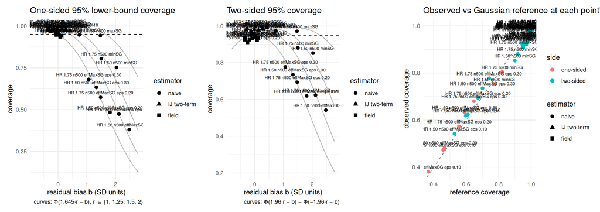

```r
tabH <- COV[COV$block == "Hhat (lower)", ]; tabH$cell <- paste(tabH$cell, tabH$setting)
fs_plot_bias_coverage(tabH, curves = c(1, 1.25, 1.5, 2), side = "lower")
```

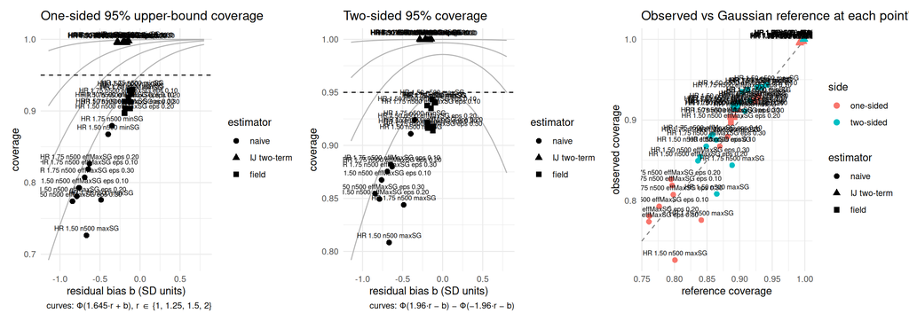

```r
tabC <- COV[COV$block == "Hhat^c (upper)", ]; tabC$cell <- paste(tabC$cell, tabC$setting)
fs_plot_bias_coverage(tabC, curves = c(1, 1.25, 1.5, 2), side = "upper")
```

# 4 Bound locations and the joint pair

```r
LOC <- do.call(rbind, lapply(names(B), function(h) do.call(rbind, lapply(names(B[[h]]), function(k) { b <- B[[h]][[k]]; if (is.null(b)) return(NULL)
  d <- b$results[b$results$detected %in% 1L, ]
  rows <- list(naive = list(lo = exp(log(d$nv_H_est) - qnorm(.95) * d$nv_H_se), up = exp(log(d$nv_Hc_est) + qnorm(.95) * d$nv_Hc_se)),
               `IJ two-term` = list(lo = exp(log(d$mr_H_est) - qnorm(.95) * d$mr_H_se_ij), up = exp(log(d$mr_Hc_est) + qnorm(.95) * d$mr_Hc_se_ij)),
               field = list(lo = d$fld_H_lo1s, up = d$fld_Hc_up1s))
  do.call(rbind, lapply(names(rows), function(nm) { p <- rows[[nm]]; ok <- is.finite(p$lo) & is.finite(p$up)
    data.frame(cell = cells[[h]], setting = lab_of(k), construction = nm, mean_betaH = mean(d$betaHhat_H), mean_betaHc = mean(d$betaHhat_Hc),
               H_lower_mean = mean(p$lo[ok]), share_ge_085 = mean(p$lo[ok] >= 0.85), share_ge_095 = mean(p$lo[ok] >= 0.95),
               Hc_upper_mean = mean(p$up[ok]), share_lt_085 = mean(p$up[ok] < 0.85), share_lt_080 = mean(p$up[ok] < 0.80), stringsAsFactors = FALSE) })) }))))
kbl(LOC, digits = 3, booktabs = TRUE, row.names = FALSE, caption = "Bound locations (HR scale): the harm lower bound against 0.85 / 0.95, the complement upper bound against 0.85 / 0.80.") |> kable_styling(font_size = 10)
```

Bound locations (HR scale): the harm lower bound against 0.85 / 0.95, the complement upper bound against 0.85 / 0.80.

| cell | setting | construction | mean_betaH | mean_betaHc | H_lower_mean | share_ge_085 | share_ge_095 | Hc_upper_mean | share_lt_085 | share_lt_080 |
| --- | --- | --- | --- | --- | --- | --- | --- | --- | --- | --- |
| HR 1.50 n500 | minSG | naive | 1.163 | 0.874 | 1.005 | 0.787 | 0.491 | 1.035 | 0.100 | 0.034 |
| HR 1.50 n500 | minSG | IJ two-term | 1.163 | 0.874 | 0.684 | 0.128 | 0.054 | 1.308 | 0.004 | 0.001 |
| HR 1.50 n500 | minSG | field | 1.163 | 0.874 | 0.712 | 0.205 | 0.115 | 1.076 | 0.048 | 0.021 |
| HR 1.50 n500 | effMaxSG eps 0.10 | naive | 1.252 | 0.835 | 1.355 | 0.994 | 0.958 | 0.941 | 0.252 | 0.144 |
| HR 1.50 n500 | effMaxSG eps 0.10 | IJ two-term | 1.252 | 0.835 | 0.725 | 0.222 | 0.120 | 1.221 | 0.012 | 0.003 |
| HR 1.50 n500 | effMaxSG eps 0.10 | field | 1.252 | 0.835 | 0.712 | 0.220 | 0.125 | 1.017 | 0.129 | 0.064 |
| HR 1.50 n500 | effMaxSG eps 0.20 | naive | 1.256 | 0.808 | 1.289 | 0.985 | 0.927 | 0.909 | 0.349 | 0.216 |
| HR 1.50 n500 | effMaxSG eps 0.20 | IJ two-term | 1.256 | 0.808 | 0.705 | 0.181 | 0.095 | 1.188 | 0.020 | 0.007 |
| HR 1.50 n500 | effMaxSG eps 0.20 | field | 1.256 | 0.808 | 0.693 | 0.196 | 0.115 | 0.987 | 0.192 | 0.109 |
| HR 1.50 n500 | effMaxSG eps 0.30 | naive | 1.228 | 0.779 | 1.173 | 0.950 | 0.835 | 0.880 | 0.428 | 0.284 |
| HR 1.50 n500 | effMaxSG eps 0.30 | IJ two-term | 1.228 | 0.779 | 0.672 | 0.127 | 0.056 | 1.159 | 0.028 | 0.011 |
| HR 1.50 n500 | effMaxSG eps 0.30 | field | 1.228 | 0.779 | 0.678 | 0.165 | 0.092 | 0.961 | 0.252 | 0.160 |
| HR 1.50 n500 | maxSG | naive | 0.977 | 0.762 | 0.837 | 0.242 | 0.036 | 1.118 | 0.432 | 0.340 |
| HR 1.50 n500 | maxSG | IJ two-term | 0.977 | 0.762 | 0.692 | 0.005 | 0.001 | 1.967 | 0.023 | 0.014 |
| HR 1.50 n500 | maxSG | field | 0.977 | 0.762 | 0.803 | 0.161 | 0.032 | 1.295 | 0.137 | 0.101 |
| HR 1.75 n500 | minSG | naive | 1.304 | 0.915 | 1.062 | 0.846 | 0.584 | 1.088 | 0.039 | 0.015 |
| HR 1.75 n500 | minSG | IJ two-term | 1.304 | 0.915 | 0.738 | 0.209 | 0.118 | 1.368 | 0.001 | 0.000 |
| HR 1.75 n500 | minSG | field | 1.304 | 0.915 | 0.790 | 0.318 | 0.206 | 1.125 | 0.025 | 0.010 |
| HR 1.75 n500 | effMaxSG eps 0.10 | naive | 1.512 | 0.848 | 1.553 | 0.999 | 0.994 | 0.969 | 0.198 | 0.106 |
| HR 1.75 n500 | effMaxSG eps 0.10 | IJ two-term | 1.512 | 0.848 | 0.854 | 0.431 | 0.293 | 1.251 | 0.011 | 0.003 |
| HR 1.75 n500 | effMaxSG eps 0.10 | field | 1.512 | 0.848 | 0.844 | 0.400 | 0.283 | 1.039 | 0.106 | 0.058 |
| HR 1.75 n500 | effMaxSG eps 0.20 | naive | 1.515 | 0.808 | 1.473 | 0.998 | 0.986 | 0.929 | 0.299 | 0.181 |
| HR 1.75 n500 | effMaxSG eps 0.20 | IJ two-term | 1.515 | 0.808 | 0.827 | 0.383 | 0.243 | 1.207 | 0.019 | 0.006 |
| HR 1.75 n500 | effMaxSG eps 0.20 | field | 1.515 | 0.808 | 0.821 | 0.371 | 0.260 | 0.999 | 0.178 | 0.104 |
| HR 1.75 n500 | effMaxSG eps 0.30 | naive | 1.454 | 0.774 | 1.337 | 0.990 | 0.950 | 0.894 | 0.402 | 0.261 |
| HR 1.75 n500 | effMaxSG eps 0.30 | IJ two-term | 1.454 | 0.774 | 0.786 | 0.311 | 0.181 | 1.171 | 0.028 | 0.008 |
| HR 1.75 n500 | effMaxSG eps 0.30 | field | 1.454 | 0.774 | 0.805 | 0.340 | 0.224 | 0.965 | 0.249 | 0.151 |
| HR 1.75 n500 | maxSG | naive | 1.014 | 0.758 | 0.852 | 0.351 | 0.082 | 1.258 | 0.330 | 0.257 |
| HR 1.75 n500 | maxSG | IJ two-term | 1.014 | 0.758 | 0.706 | 0.015 | 0.001 | 2.321 | 0.019 | 0.009 |
| HR 1.75 n500 | maxSG | field | 1.014 | 0.758 | 0.828 | 0.271 | 0.079 | 1.389 | 0.143 | 0.102 |

```r
JNT <- do.call(rbind, lapply(names(B), function(h) do.call(rbind, lapply(names(B[[h]]), function(k) { b <- B[[h]][[k]]; if (is.null(b)) return(NULL)
  r <- b$results; d <- r[r$detected %in% 1L & is.finite(r$betaHhat_H) & is.finite(r$betaHhat_Hc) & is.finite(r$fld_joint_gamma), ]
  pairs <- list(`separate 95%` = list(lo = d$fld_H_lo1s, up = d$fld_Hc_up1s), Bonferroni = list(lo = d$fld_joint_bonf_loH, up = d$fld_joint_bonf_upHc), calibrated = list(lo = d$fld_joint_loH, up = d$fld_joint_upHc))
  do.call(rbind, lapply(names(pairs), function(nm) { p <- pairs[[nm]]; cH <- d$betaHhat_H >= p$lo; cC <- d$betaHhat_Hc <= p$up; jc <- mean(cH & cC); w <- wil(jc, nrow(d))
    data.frame(cell = cells[[h]], setting = lab_of(k), pair = nm, n = nrow(d), joint_cov = jc, wilson_lo = w[1], wilson_hi = w[2], cov_H = mean(cH), cov_Hc = mean(cC),
               margin_H = mean(log(d$mr_H_est) - log(p$lo)), margin_Hc = mean(log(p$up) - log(d$mr_Hc_est)), mean_gamma = mean(d$fld_joint_gamma), mean_corr = mean(d$fld_joint_corr), stringsAsFactors = FALSE) })) }))))
kbl(JNT, digits = 3, booktabs = TRUE, row.names = FALSE, caption = "Joint coverage of (beta(Hhat) >= lower_H, beta(Hhat^c) <= upper_Hc), Wilson limits.") |> kable_styling(font_size = 10)
```

Joint coverage of (beta(Hhat) >= lower_H, beta(Hhat^c) <= upper_Hc), Wilson limits.

| cell | setting | pair | n | joint_cov | wilson_lo | wilson_hi | cov_H | cov_Hc | margin_H | margin_Hc | mean_gamma | mean_corr |
| --- | --- | --- | --- | --- | --- | --- | --- | --- | --- | --- | --- | --- |
| HR 1.50 n500 | minSG | separate 95% | 1999 | 0.869 | 0.854 | 0.883 | 0.942 | 0.923 | 0.602 | 0.221 | 0.025 | 0.029 |
| HR 1.50 n500 | minSG | Bonferroni | 1999 | 0.939 | 0.928 | 0.949 | 0.972 | 0.965 | 0.717 | 0.261 | 0.025 | 0.029 |
| HR 1.50 n500 | minSG | calibrated | 1999 | 0.938 | 0.927 | 0.948 | 0.971 | 0.965 | 0.717 | 0.261 | 0.025 | 0.029 |
| HR 1.50 n500 | effMaxSG eps 0.10 | separate 95% | 1999 | 0.884 | 0.870 | 0.898 | 0.970 | 0.913 | 0.664 | 0.229 | 0.025 | 0.046 |
| HR 1.50 n500 | effMaxSG eps 0.10 | Bonferroni | 1999 | 0.940 | 0.929 | 0.950 | 0.988 | 0.952 | 0.803 | 0.271 | 0.025 | 0.046 |
| HR 1.50 n500 | effMaxSG eps 0.10 | calibrated | 1999 | 0.939 | 0.928 | 0.949 | 0.987 | 0.951 | 0.802 | 0.271 | 0.025 | 0.046 |
| HR 1.50 n500 | effMaxSG eps 0.20 | separate 95% | 1999 | 0.872 | 0.857 | 0.886 | 0.974 | 0.897 | 0.624 | 0.237 | 0.025 | 0.041 |
| HR 1.50 n500 | effMaxSG eps 0.20 | Bonferroni | 1999 | 0.932 | 0.920 | 0.942 | 0.989 | 0.942 | 0.762 | 0.280 | 0.025 | 0.041 |
| HR 1.50 n500 | effMaxSG eps 0.20 | calibrated | 1999 | 0.932 | 0.920 | 0.942 | 0.989 | 0.942 | 0.761 | 0.279 | 0.025 | 0.041 |
| HR 1.50 n500 | effMaxSG eps 0.30 | separate 95% | 1999 | 0.886 | 0.872 | 0.900 | 0.980 | 0.904 | 0.555 | 0.248 | 0.025 | 0.039 |
| HR 1.50 n500 | effMaxSG eps 0.30 | Bonferroni | 1999 | 0.935 | 0.923 | 0.945 | 0.993 | 0.941 | 0.691 | 0.294 | 0.025 | 0.039 |
| HR 1.50 n500 | effMaxSG eps 0.30 | calibrated | 1999 | 0.935 | 0.923 | 0.945 | 0.993 | 0.941 | 0.690 | 0.294 | 0.025 | 0.039 |
| HR 1.50 n500 | maxSG | separate 95% | 1999 | 0.881 | 0.867 | 0.895 | 0.949 | 0.928 | 0.210 | 0.536 | 0.026 | 0.026 |
| HR 1.50 n500 | maxSG | Bonferroni | 1999 | 0.937 | 0.925 | 0.947 | 0.974 | 0.962 | 0.248 | 0.653 | 0.026 | 0.026 |
| HR 1.50 n500 | maxSG | calibrated | 1999 | 0.936 | 0.924 | 0.946 | 0.974 | 0.961 | 0.247 | 0.649 | 0.026 | 0.026 |
| HR 1.75 n500 | minSG | separate 95% | 1999 | 0.869 | 0.854 | 0.883 | 0.936 | 0.929 | 0.589 | 0.218 | 0.025 | 0.020 |
| HR 1.75 n500 | minSG | Bonferroni | 1999 | 0.930 | 0.918 | 0.940 | 0.965 | 0.963 | 0.702 | 0.258 | 0.025 | 0.020 |
| HR 1.75 n500 | minSG | calibrated | 1999 | 0.929 | 0.917 | 0.940 | 0.964 | 0.963 | 0.701 | 0.258 | 0.025 | 0.020 |
| HR 1.75 n500 | effMaxSG eps 0.10 | separate 95% | 1999 | 0.886 | 0.871 | 0.899 | 0.964 | 0.919 | 0.651 | 0.227 | 0.025 | 0.028 |
| HR 1.75 n500 | effMaxSG eps 0.10 | Bonferroni | 1999 | 0.940 | 0.929 | 0.950 | 0.987 | 0.952 | 0.788 | 0.269 | 0.025 | 0.028 |
| HR 1.75 n500 | effMaxSG eps 0.10 | calibrated | 1999 | 0.940 | 0.929 | 0.950 | 0.987 | 0.952 | 0.787 | 0.268 | 0.025 | 0.028 |
| HR 1.75 n500 | effMaxSG eps 0.20 | separate 95% | 1999 | 0.885 | 0.870 | 0.898 | 0.970 | 0.912 | 0.611 | 0.234 | 0.025 | 0.019 |
| HR 1.75 n500 | effMaxSG eps 0.20 | Bonferroni | 1999 | 0.933 | 0.922 | 0.944 | 0.986 | 0.947 | 0.747 | 0.276 | 0.025 | 0.019 |
| HR 1.75 n500 | effMaxSG eps 0.20 | calibrated | 1999 | 0.933 | 0.921 | 0.943 | 0.986 | 0.946 | 0.746 | 0.276 | 0.025 | 0.019 |
| HR 1.75 n500 | effMaxSG eps 0.30 | separate 95% | 1999 | 0.881 | 0.867 | 0.895 | 0.976 | 0.903 | 0.542 | 0.245 | 0.025 | 0.012 |
| HR 1.75 n500 | effMaxSG eps 0.30 | Bonferroni | 1999 | 0.935 | 0.923 | 0.945 | 0.992 | 0.943 | 0.676 | 0.290 | 0.025 | 0.012 |
| HR 1.75 n500 | effMaxSG eps 0.30 | calibrated | 1999 | 0.935 | 0.923 | 0.945 | 0.992 | 0.943 | 0.675 | 0.290 | 0.025 | 0.012 |
| HR 1.75 n500 | maxSG | separate 95% | 1999 | 0.876 | 0.861 | 0.890 | 0.947 | 0.925 | 0.204 | 0.584 | 0.026 | 0.035 |
| HR 1.75 n500 | maxSG | Bonferroni | 1999 | 0.942 | 0.931 | 0.952 | 0.975 | 0.966 | 0.243 | 0.710 | 0.026 | 0.035 |
| HR 1.75 n500 | maxSG | calibrated | 1999 | 0.941 | 0.930 | 0.951 | 0.975 | 0.965 | 0.241 | 0.706 | 0.026 | 0.035 |

# 5 The size distribution across the dial

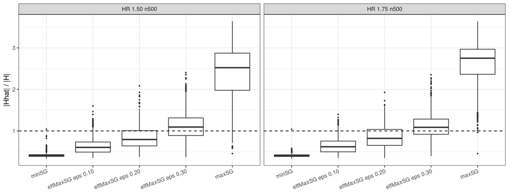

```r
SZ <- do.call(rbind, lapply(names(B), function(h) do.call(rbind, lapply(names(B[[h]]), function(k) { b <- B[[h]][[k]]; if (is.null(b)) return(NULL)
  d <- b$results[b$results$detected %in% 1L, ]; data.frame(cell = cells[[h]], setting = lab_of(k), ratio = d$n_harm / d$n_true) }))))
SZ$setting <- factor(SZ$setting, levels = vapply(settings, `[[`, "", "label"))
ggplot(SZ, aes(x = setting, y = ratio)) + geom_boxplot(outlier.size = 0.5) + geom_hline(yintercept = 1, linetype = 2) + facet_wrap(~ cell) +
  labs(x = NULL, y = "|Hhat| / |H|") + theme_bw(base_size = 11) + theme(axis.text.x = element_text(angle = 20, hjust = 1))
```

# 6 Numbers for the record

**HR 1.50 n500** (n common 1999)

- detection (all replicates): 1.000 | 1.000 | 1.000 | 1.000 | 1.000
- n (common detected): 1999.000 | 1999.000 | 1999.000 | 1999.000 | 1999.000
- mean |Hhat|: 62.534 | 97.341 | 127.123 | 168.881 | 367.340
- |Hhat|/|H| median: 0.407 | 0.604 | 0.793 | 1.093 | 2.523
- |Hhat|/|H| q10: 0.372 | 0.429 | 0.525 | 0.704 | 1.538
- |Hhat|/|H| q90: 0.449 | 0.927 | 1.179 | 1.483 | 3.068
- share |Hhat| >= |H| (planted size): 0.001 | 0.064 | 0.264 | 0.634 | 0.989
- share |Hhat| >= 0.9|H|: 0.001 | 0.113 | 0.391 | 0.743 | 0.993
- sens: 0.248 | 0.450 | 0.590 | 0.737 | 0.915
- spec: 0.929 | 0.917 | 0.893 | 0.838 | 0.344
- ppv: 0.603 | 0.697 | 0.706 | 0.682 | 0.402
- npv: 0.737 | 0.794 | 0.837 | 0.883 | 0.915
- naive optimism Hhat: log-HR: 0.384 | 0.548 | 0.430 | 0.299 | 0.082
- naive optimism Hhat: SD units (marginal): 2.032 | 2.478 | 1.809 | 1.332 | 1.472
- naive optimism Hhat: error-SD units: 1.528 | 1.977 | 1.530 | 1.225 | 0.896
- naive optimism Hhat^c: log-HR: -0.056 | -0.112 | -0.123 | -0.137 | -0.225
- naive optimism Hhat^c: SD units (marginal): -0.398 | -0.762 | -0.789 | -0.844 | -0.669
- mean beta(Hhat): 1.163 | 1.252 | 1.256 | 1.228 | 0.977
- theta-dagger(H): 1.499 | 1.499 | 1.499 | 1.499 | 1.499
- mean beta(Hhat^c): 0.874 | 0.835 | 0.808 | 0.779 | 0.762
- theta-dagger(H^c): 0.721 | 0.721 | 0.721 | 0.721 | 0.721
- SD(beta-tilde^c)/naive SE (marginal): 1.061 | 1.080 | 1.098 | 1.066 | 1.004
- SD(e^c)/naive SE (error): 1.035 | 1.005 | 1.011 | 1.003 | 1.024
- lambda-SD^c/naive SE: 0.992 | 0.969 | 0.947 | 0.917 | 1.020
- SD(beta-tilde)/naive SE (marginal, Hhat): 0.733 | 0.939 | 1.098 | 1.175 | 0.455
- SD(e)/naive SE (error, Hhat): 0.897 | 1.058 | 1.192 | 1.190 | 0.868
- p-hat(Hhat) mean: 0.092 | NaN | 0.103 | 0.064 | 0.291
- p-hat(Hhat) median: 0.043 | NA | 0.069 | 0.042 | 0.127
- share p-hat = argmax: 0.098 | NaN | 0.254 | 0.153 | 0.394
- top-3 mass: 0.735 | 0.000 | 0.364 | 0.299 | 0.555
- band size (eps of the bundle): 3.353 | NaN | 10.306 | 29.074 | 3.353
- consistency-qualifying: 202.425 | NaN | 202.425 | 202.425 | 202.425
- family K: 1228.432 | NaN | 1228.432 | 1228.432 | 1228.432
- complement fits/rep: 132.980 | 483.966 | 615.019 | 748.540 | 585.665
- fit+MR s/rep: 51.597 | 71.025 | 72.169 | 73.128 | 54.402

**HR 1.75 n500** (n common 1999)

- detection (all replicates): 1.000 | 1.000 | 1.000 | 1.000 | 1.000
- n (common detected): 1999.000 | 1999.000 | 1999.000 | 1999.000 | 1999.000
- mean |Hhat|: 61.824 | 99.267 | 128.930 | 166.818 | 401.556
- |Hhat|/|H| median: 0.404 | 0.618 | 0.821 | 1.087 | 2.752
- |Hhat|/|H| q10: 0.370 | 0.430 | 0.536 | 0.701 | 1.927
- |Hhat|/|H| q90: 0.445 | 0.949 | 1.163 | 1.426 | 3.131
- share |Hhat| >= |H| (planted size): 0.001 | 0.069 | 0.302 | 0.647 | 0.999
- share |Hhat| >= 0.9|H|: 0.001 | 0.135 | 0.429 | 0.768 | 0.999
- sens: 0.249 | 0.506 | 0.660 | 0.792 | 0.948
- spec: 0.931 | 0.936 | 0.919 | 0.868 | 0.260
- ppv: 0.613 | 0.767 | 0.779 | 0.740 | 0.372
- npv: 0.738 | 0.815 | 0.866 | 0.909 | 0.936
- naive optimism Hhat: log-HR: 0.326 | 0.483 | 0.365 | 0.254 | 0.046
- naive optimism Hhat: SD units (marginal): 1.504 | 2.120 | 1.481 | 1.065 | 0.739
- naive optimism Hhat: error-SD units: 1.199 | 1.673 | 1.241 | 1.001 | 0.488
- naive optimism Hhat^c: log-HR: -0.049 | -0.098 | -0.102 | -0.113 | -0.191
- naive optimism Hhat^c: SD units (marginal): -0.350 | -0.645 | -0.631 | -0.691 | -0.487
- mean beta(Hhat): 1.304 | 1.512 | 1.515 | 1.454 | 1.014
- theta-dagger(H): 1.746 | 1.746 | 1.746 | 1.746 | 1.746
- mean beta(Hhat^c): 0.915 | 0.848 | 0.808 | 0.774 | 0.758
- theta-dagger(H^c): 0.721 | 0.721 | 0.721 | 0.721 | 0.721
- SD(beta-tilde^c)/naive SE (marginal): 1.057 | 1.116 | 1.135 | 1.094 | 1.038
- SD(e^c)/naive SE (error): 1.028 | 1.013 | 1.022 | 1.016 | 1.052
- lambda-SD^c/naive SE: 0.994 | 0.967 | 0.946 | 0.925 | 0.988
- SD(beta-tilde)/naive SE (marginal, Hhat): 0.802 | 1.003 | 1.175 | 1.270 | 0.594
- SD(e)/naive SE (error, Hhat): 0.949 | 1.129 | 1.282 | 1.258 | 0.915
- p-hat(Hhat) mean: 0.086 | NaN | 0.119 | 0.080 | 0.415
- p-hat(Hhat) median: 0.033 | NA | 0.083 | 0.055 | 0.299
- share p-hat = argmax: 0.086 | NaN | 0.283 | 0.181 | 0.541
- top-3 mass: 0.784 | 0.000 | 0.395 | 0.334 | 0.661
- band size (eps of the bundle): 3.292 | NaN | 9.908 | 27.823 | 3.292
- consistency-qualifying: 276.858 | NaN | 276.858 | 276.858 | 276.858
- family K: 1228.432 | NaN | 1228.432 | 1228.432 | 1228.432
- complement fits/rep: 97.821 | 456.810 | 580.252 | 707.839 | 464.563
- fit+MR s/rep: 52.823 | 74.143 | 75.426 | 75.897 | 55.306